# DAB501 Project 2

# *Bivariate Analysis*

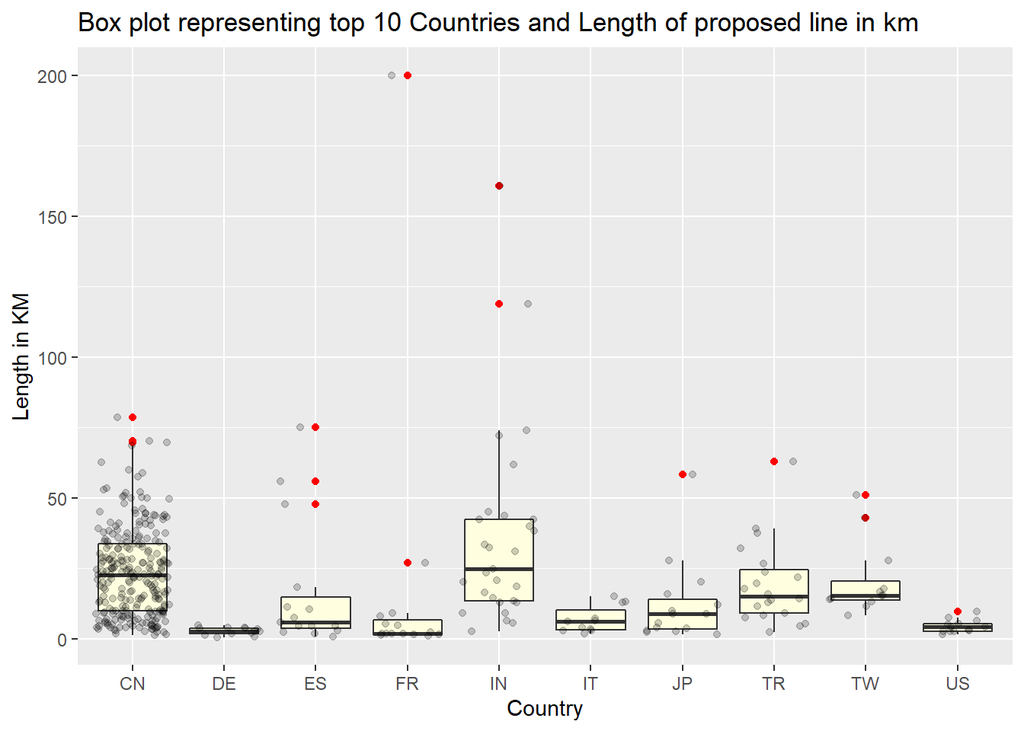

```r
country_count %>%
  drop_na(country) %>%
  ggplot(mapping = aes(x = country, y = length)) +
  geom_boxplot(outlier.color = "red", fill = "light yellow")+
  labs(title = "Box plot representing top 10 Countries and Length of proposed line in km",
       x = "Country",
       y = "Length in KM")+
  geom_jitter(alpha = 0.2)
```

The box plot shows relationship between top 10 countries based on number of projects and the length of transit line constructed in kilometer. Even though more number of projects are in China, India and France have some of the longest transit line under construction, whereas, Germany and United States have very small length of transit lines.  
More variation in transit length can be seen for China and India, while all the other countries have very less variation.  
Form and direction can not be defined because of the presence of one categorical variable.

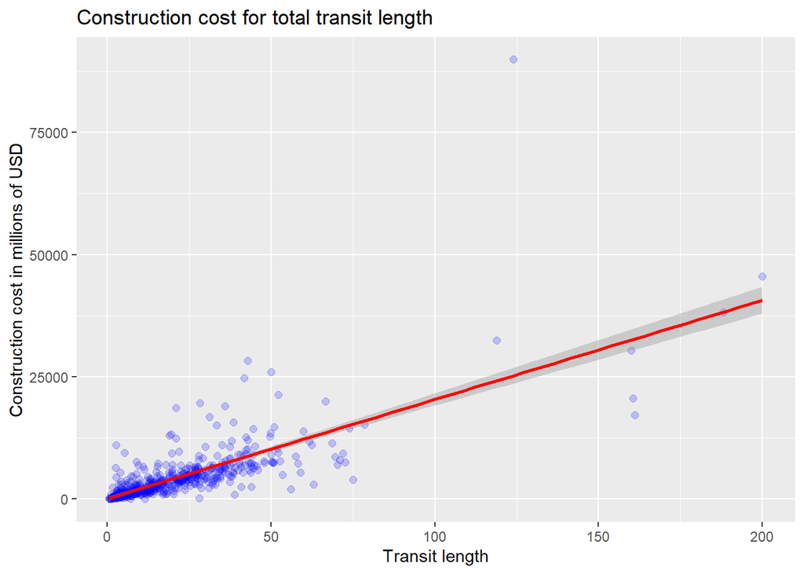

```r
transit_cost %>%
  ggplot(aes(x= length, y = real_cost))+
  geom_point(alpha = 0.2, color = "blue", size = 2)+
  geom_smooth(method = 'lm', color = "red")+
  labs(title = "Construction cost for total transit length",
       x = "Transit length",
       y = "Construction cost in millions of USD")
```

```r
cor(transit_cost$length, transit_cost$real_cost)
```

```
## [1] 0.7478688
```

Relationship between Countries and transit length cannot be explained properly if we do not know the relationship between transit length and its construction cost. From the above scatter plot we can say that with increase in Transit length the cost of construction also increases. Large amount of points can be seen concentrated near the origin of the plot where transit length is less than 50km and construction cost is below 25000 million USD. There are very few transits where the cost of its construction is above 40000 million USD. And only one case where the transit length is around 125km which is not the longest one but have highest construction cost of more than 90000 million USD, which can also be called as an outlier.  
Relationship between both the variable is linear and its direction is positive.  
Correlation value for the above plot is 0.7478688 which is a strong relationship.

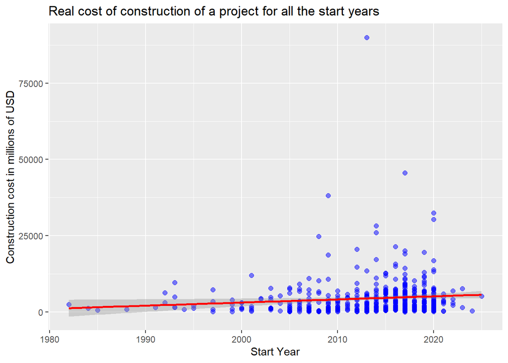

```r
transit_cost %>%
  ggplot(aes(x= start_year, y = real_cost))+
  geom_point(alpha = 0.5, color = "blue", size = 2)+
  geom_smooth(method = 'lm', color = "red")+
  labs(title = "Real cost of construction of a project for all the start years",
       x = "Start Year",
       y = "Construction cost in millions of USD")
```

```r
cor(transit_cost$start_year, transit_cost$real_cost, use = "complete.obs")
```

```
## [1] 0.1072651
```

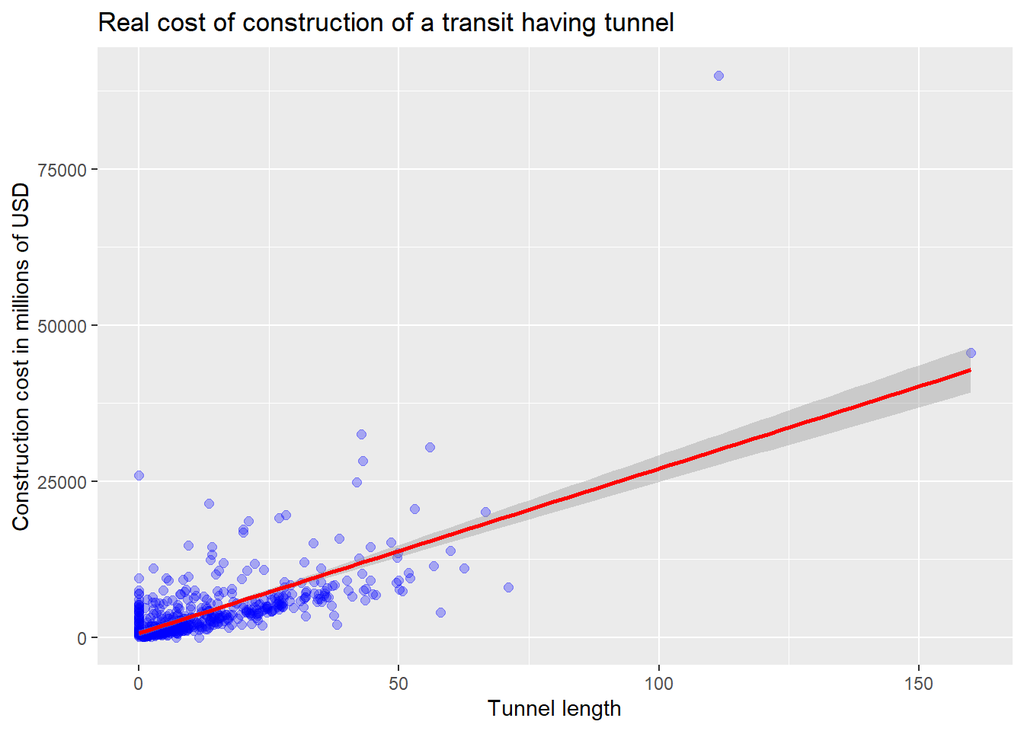

```r
transit_cost %>%
  ggplot(aes(x= tunnel, y = real_cost))+
  geom_point(alpha = 0.3, color = "blue", size = 2)+
  geom_smooth(method = 'lm', color = "red")+
  labs(title = "Real cost of construction of a transit having tunnel",
       x = "Tunnel length",
       y = "Construction cost in millions of USD")
```